# PCA

Chase Enzweiler

9/18/2017

# Principal Component Analysis

```r
wholesale <- read.csv("~/Desktop/stat 154/wholesale.csv")
```

convert channel and region variables to factors

```r
# factor and horeca = 1 and retail = 2
wholesale$Channel[wholesale$Channel == 1] <- "Horeca"
wholesale$Channel[wholesale$Channel == 2] <- "Retail"
wholesale$Channel <- as.factor(wholesale$Channel)

# 1= lisbon, 2 = oporto, 3 = other
wholesale$Region[wholesale$Region == 1] <- "Lisbon"
wholesale$Region[wholesale$Region == 2] <- "Oporto"
wholesale$Region[wholesale$Region == 3] <- "Other"
wholesale$Region <- as.factor(wholesale$Region)
```

perform exploratory data analysis

```r
#summary statistics
summary(wholesale)
```

```
##    Channel       Region        Fresh             Milk
##  Horeca:298   Lisbon: 77   Min.   :     3   Min.   :   55
##  Retail:142   Oporto: 47   1st Qu.:  3128   1st Qu.: 1533
##               Other :316   Median :  8504   Median : 3627
##                            Mean   : 12000   Mean   : 5796
##                            3rd Qu.: 16934   3rd Qu.: 7190
##                            Max.   :112151   Max.   :73498
##     Grocery          Frozen        Detergents_Paper    Delicassen
##  Min.   :    3   Min.   :   25.0   Min.   :    3.0   Min.   :    3.0
##  1st Qu.: 2153   1st Qu.:  742.2   1st Qu.:  256.8   1st Qu.:  408.2
##  Median : 4756   Median : 1526.0   Median :  816.5   Median :  965.5
##  Mean   : 7951   Mean   : 3071.9   Mean   : 2881.5   Mean   : 1524.9
##  3rd Qu.:10656   3rd Qu.: 3554.2   3rd Qu.: 3922.0   3rd Qu.: 1820.2
##  Max.   :92780   Max.   :60869.0   Max.   :40827.0   Max.   :47943.0
```

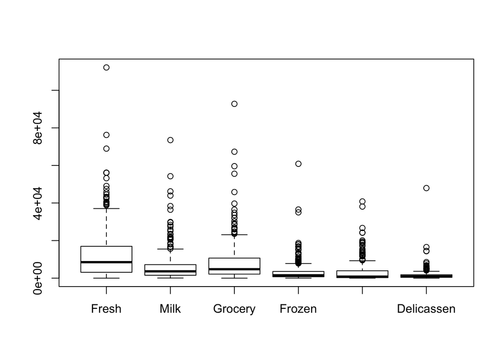

```r
#boxplots for quant. varibles and standardized quant. variables
boxplot(wholesale[,3:8])
```

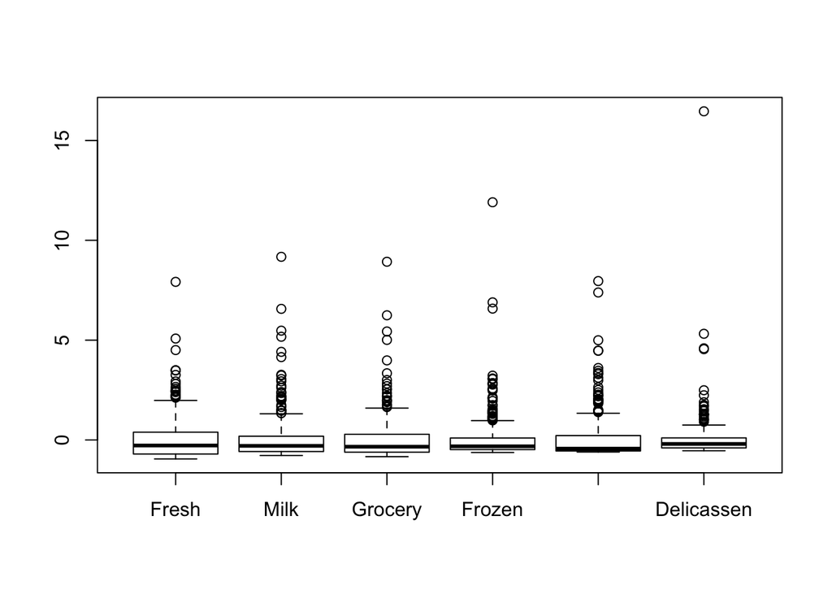

```r
boxplot(scale(wholesale[,3:8]))
```

```r
# correlation matrix
cor(wholesale[,3:8])
```

```
##                        Fresh      Milk     Grocery      Frozen
## Fresh             1.00000000 0.1005098 -0.01185387  0.34588146
## Milk              0.10050977 1.0000000  0.72833512  0.12399376
## Grocery          -0.01185387 0.7283351  1.00000000 -0.04019274
## Frozen            0.34588146 0.1239938 -0.04019274  1.00000000
## Detergents_Paper -0.10195294 0.6618157  0.92464069 -0.13152491
## Delicassen        0.24468997 0.4063683  0.20549651  0.39094747
##                  Detergents_Paper Delicassen
## Fresh                  -0.1019529  0.2446900
## Milk                    0.6618157  0.4063683
## Grocery                 0.9246407  0.2054965
## Frozen                 -0.1315249  0.3909475
## Detergents_Paper        1.0000000  0.0692913
## Delicassen              0.0692913  1.0000000
```

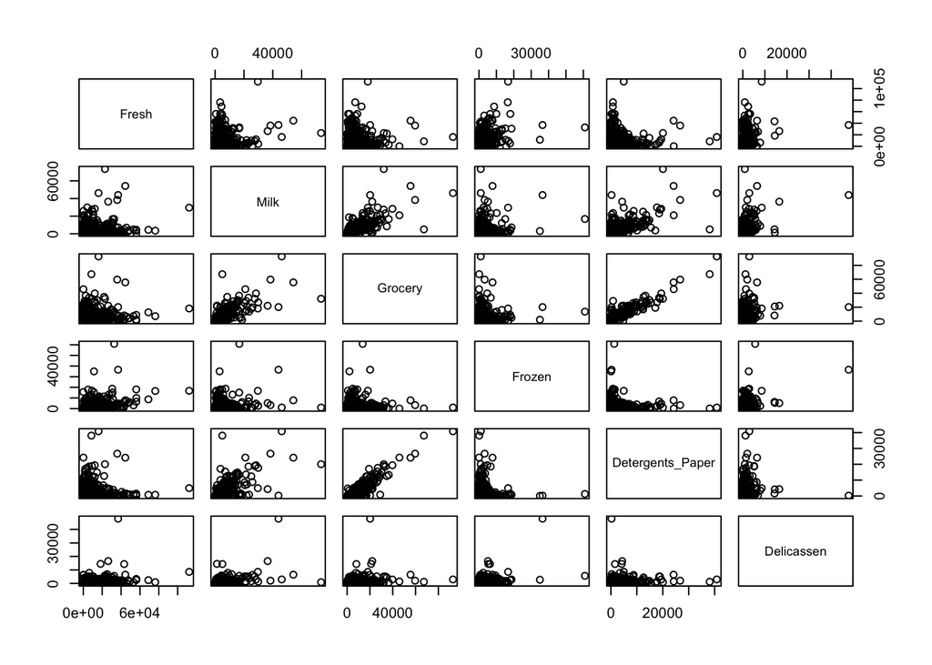

```r
# pairs plot
pairs(wholesale[,3:8])
```

### PCA with prcomp()

What are the differences between prcomp() and princomp()?  
Princomp() is calculated using eigen decomposition of a correlation matrix (1/n)t(x)x or covariance matrix. it is done for compatibility with SPLUS. it uses divisor n for the covariance matrix. It prints results in a nice format to and has plot methods to produce scree plots and a biplot method. May not necesarilly center data beforehand? prints the number of observations  
prcomp() is calculated using singular value decomposition and not eigen decompostition on a covariance matrix. SVD is used for numerical accuracy. print method prints in a nice format and has a plot method for scree plots. Variances are computed using the divisor N - 1  
it would be better to use prcomp() most of the time because it uses SVD which produces better numerical accuracy. princomp may be better sometimes if we wanted to create a biplot because it has a biplot method.  
## Stages of PCA

```r
pca <- prcomp(wholesale[,3:8], scale. = TRUE)

# eigenvalues are the variances of the pc's
eigenvalues <- (pca$sdev)^2
proportion <- eigenvalues/6

cum_prop <- c(proportion[1])

for(i in 2:6){
  cum_prop <- append(cum_prop, sum(proportion[1:i]))
}

eigenvalue_table <- cbind(eigenvalues, proportion, cum_prop)
rownames(eigenvalue_table) <- paste("PC", 1:6, sep = "")

eigenvalue_table <- as.table(eigenvalue_table)

eigenvalue_table
```

```
##     eigenvalues proportion   cum_prop
## PC1  2.64497357 0.44082893 0.44082893
## PC2  1.70258397 0.28376400 0.72459292
## PC3  0.74006477 0.12334413 0.84793705
## PC4  0.56373023 0.09395504 0.94189209
## PC5  0.28567634 0.04761272 0.98950481
## PC6  0.06297111 0.01049519 1.00000000
```

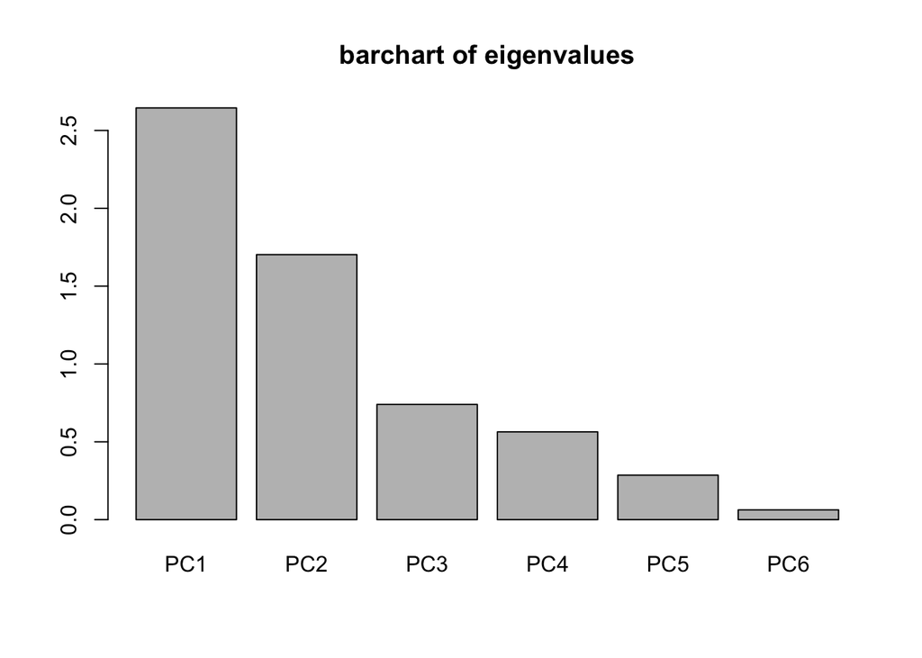

```r
barplot(eigenvalue_table[,1], main = "barchart of eigenvalues")
```

### Choosing the number of components

- to capture 70 percent of the total variatiion we would choose two PC’s

```r
#eigenvalue average
sum(eigenvalues)/6
```

```
## [1] 1
```

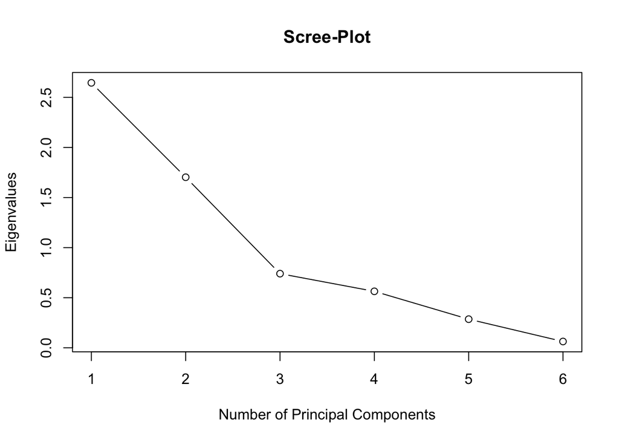

```r
plot(1:6, eigenvalues, ylab = "Eigenvalues", type = "b", xlab = "Number of Principal Components", main = "Scree-Plot")
```

## Variable loadings and correlations with PC’s

```r
# calculate the correlations between the active variables and the Pc's

correlations <- cor(wholesale[,3:8], pca$x)
```

graph the circle of correlations

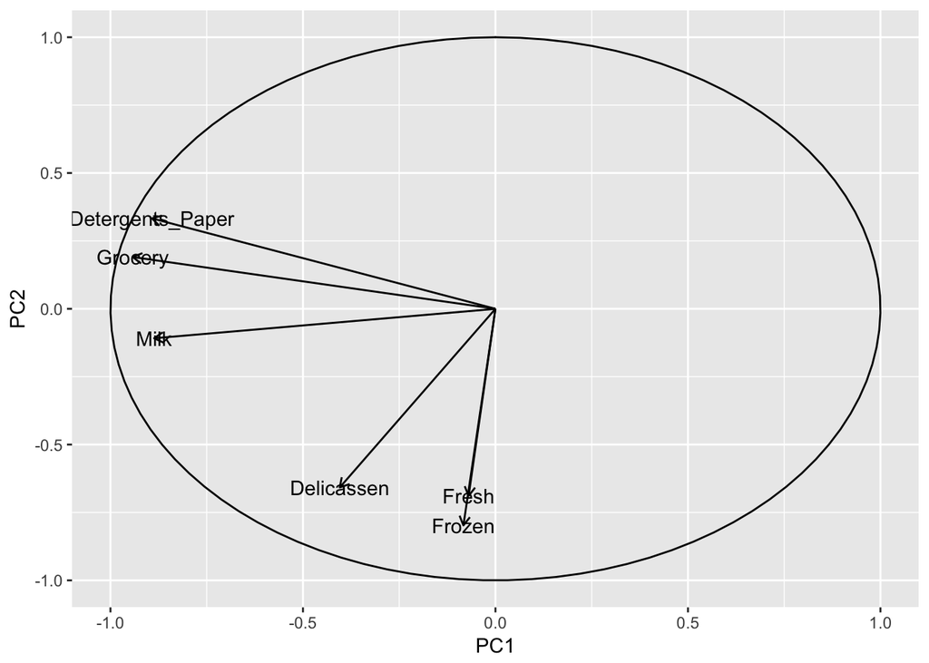

```r
library(ggplot2)
correlations <- as.data.frame(correlations)

radians <- seq(0, 2*pi, length = 100)
circle_frame <- data.frame(x = sin(radians), y = cos(radians))

ggplot(data = correlations, aes(PC1, PC2)) + geom_segment(data = correlations, aes(x = 0, y = 0, xend = PC1, yend = PC2), arrow = arrow(length = unit(0.2, "cm"))) + geom_polygon(aes(x,y), data = circle_frame, color = "black", fill = NA)  +
  geom_text(data = correlations, label = rownames(correlations))
```

```r
# contributions of observations
contr <- t(t(pca$x ^ 2) / eigenvalues)

contr[1:6,]
```

```
##              PC1        PC2         PC3        PC4       PC5          PC6
## [1,] 0.014093269 0.05454910 0.026756620 0.41877812 0.8567256 0.0008709474
## [2,] 0.071188513 0.06320377 0.137196013 0.05660086 0.4667677 0.0471854145
## [3,] 0.248190759 0.38933237 3.128808032 2.78350544 0.5018092 1.2204421228
## [4,] 0.228703423 0.24969051 0.035824712 0.25564956 0.2663107 0.0584115578
## [5,] 0.010430580 0.94730701 0.005922419 1.20820043 0.5427431 0.0114008784
## [6,] 0.009199947 0.05104608 0.029375488 0.30966487 0.8028474 0.0460996372
```

delete observations with contributions of 10 or more on PC1

```r
rows_to_del <- which(contr[,1] >= 10)

wholesale2 <- wholesale[-rows_to_del,]
```

now perform all the before steps on the data wholesale2

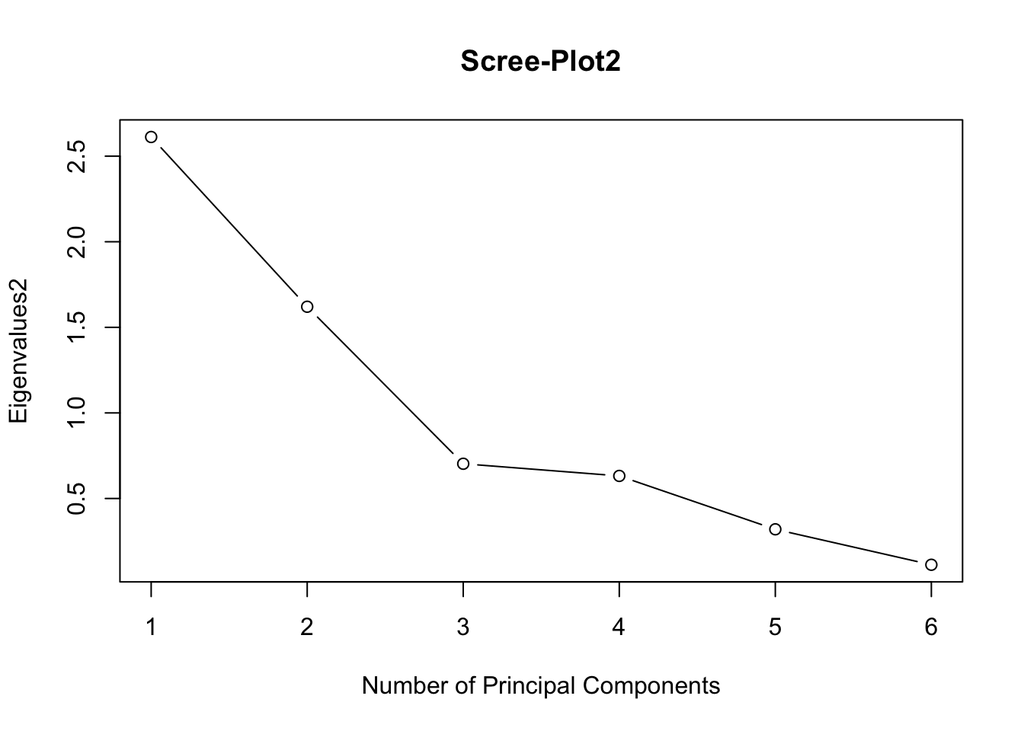

```r
pca2 <- prcomp(wholesale2[,3:8], scale. = TRUE)

eigenvalues2 <- pca2$sdev ^ 2

proportion2 <- eigenvalues2/6

cum_prop2 <- c(proportion2[1])

for(i in 2:6){
  cum_prop <- append(cum_prop2, sum(proportion2[1:i]))
}

plot(1:6, eigenvalues2, ylab = "Eigenvalues2", type = "b", xlab = "Number of Principal Components", main = "Scree-Plot2")
```

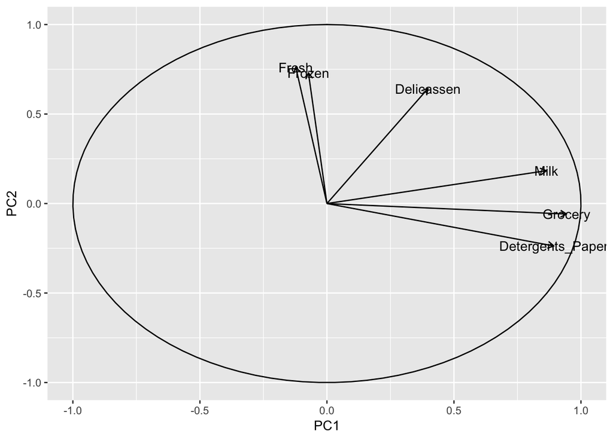

```r
correlations2 <- cor(wholesale2[,3:8], pca2$x)


correlations2 <- as.data.frame(correlations2)

radians <- seq(0, 2*pi, length = 100)
circle_frame <- data.frame(x = sin(radians), y = cos(radians))

ggplot(data = correlations2, aes(PC1, PC2)) + geom_segment(data = correlations2, aes(x = 0, y = 0, xend = PC1, yend = PC2), arrow = arrow(length = unit(0.2, "cm"))) + geom_polygon(aes(x,y), data = circle_frame, color = "black", fill = NA)  +
  geom_text(data = correlations2, label = rownames(correlations2))
```

biplot

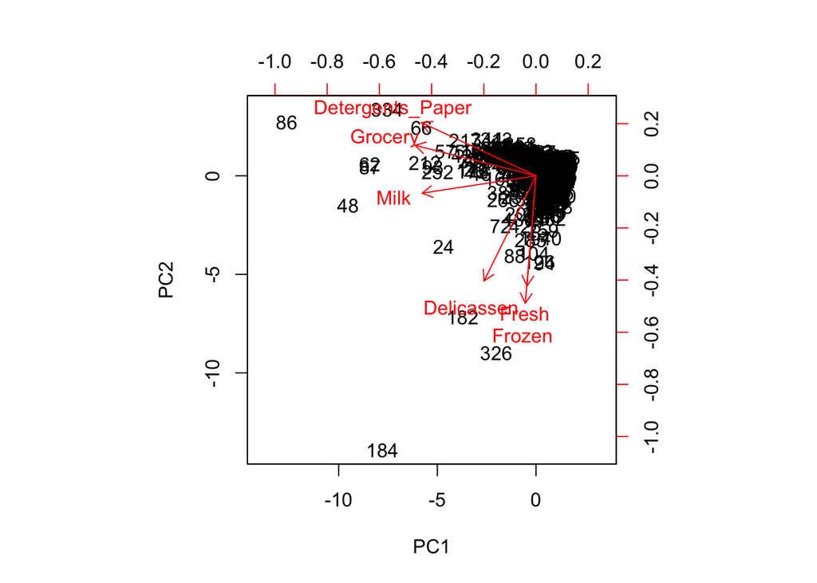

```r
biplot(pca, scale = 0)
```